# Political Trust and the Acceptance of State Surveillance

Yue He

# Abstract

This paper examines the relationship between political trust and public acceptance of state surveillance, focusing on video surveillance in public areas. Using data from the 2017 European Values Study, the analysis employs ordinal logistic regression to test the hypothesis that higher political trust predicts greater support for surveillance. The core analysis of Germany reveals a modest negative relationship, contradicting the initial hypothesis. A comparative analysis with Sweden, Poland, and Italy shows that while the negative direction is consistent, the effect’s strength and significance vary, being strongest in Poland. The findings suggest that the theorized link between trust and acceptance of state power is not universal and is critically shaped by national context.

# Introduction

The balance between national security and individual privacy is a defining debate of our time. In order to address security concerns, governments around the world are expanding their surveillance capabilities. However, public acceptance of such measures is not automatic; it is influenced by complex social and political factors. This paper focuses on one key factor—Political Trust. It investigates the extent to which citizens’ trust in political institutions shapes their willingness to authorize governments to monitor public spaces. The core research question is: How does political trust influence public support for government video surveillance in public areas? Furthermore, does this relationship hold across different national contexts?

To answer these questions, this study employs a comparative design. Germany serves as the primary case for in-depth analysis, providing a detailed examination of the trust-surveillance link. This is because, as Europe’s largest economy with a mature and stable democratic system, it maintains a moderately high level of political trust. Simultaneously, due to the historical influence, Germany has developed a unique equilibrium between privacy rights and security.

This focused approach is then complemented by comparisons with Sweden, Poland, and Italy. Further research is needed to explore potential variations in this relationship across different European contexts and political cultures.

# Theoretical Framework and Literature Review

Political trust acts as a crucial psychological mechanism that lowers public resistance to the expansion of state power. When citizens have high trust, they are more likely to perceive surveillance measures as legitimate and necessary for safety, rather than as tools for potential oppression. This leads to the first hypothesis: H1: Higher levels of political trust are associated with greater public support for video surveillance in public areas.

Not all surveillance measures are perceived equally. This study proposes an “intrusiveness gradient.” Monitoring public spaces is arguably less intrusive than monitoring private digital communications, which is in turn less intrusive than secretly collecting personal information without knowledge. This study assumes the effect of trust to be strongest for the least intrusive measure and weaken as intrusiveness increases.

H2: The positive effect of political trust on support for surveillance will weaken as the intrusiveness of the surveillance measure increases (from public area surveillance to internet monitoring to collecting information without knowledge).

Finally, national political contexts—shaped by history, culture, and current events—likely moderate these relationships. Germany’s history with state oppression (e.g., the Stasi in East Germany) may cultivate a skepticism toward state monitoring that outweighs the influence of trust. In contrast, countries without such a recent historical burden might exhibit a more positive trust-acceptance relationship. This leads to the comparative research question: This leads to the comparative research question: Does the relationship between political trust and support for public surveillance differ significantly in strength between Germany, Sweden, Poland, and Italy?

# Data, Variables, and Methods

## Data

This study uses data from the 2017 European Values Study. The analysis focuses on four countries: Germany (DE), Sweden (SE), Poland (PL), and Italy (IT). The initial pooled sample of 6,993 respondents was cleaned by removing cases with missing values on key variables, resulting in a final analytic sample of 6,025 respondents.

## Variables

• Dependent Variables: The primary outcome is support for public video surveillance, measured by EVS variable v205 (“government: public area under video surveillance”). Responses were originally coded from 1 (“definitely should have the right”) to 4 (“definitely should not have the right”). For intuitive interpretation, this variable was reverse-coded so that higher values (1-4) indicate stronger support. It is treated as an ordered factor. For robustness, v206 (“government: monitor all information exchanged on the internet”) and v207 (“government: collect information about anyone without their knowledge”) were processed identically. • Core Independent Variable: Political trust is measured by EVS variable v130 (“how much confidence in: political parties”). Responses range from 1 (“none at all”) to 4 (“a great deal”), treated as a continuous numeric variable. • Control Variables: Several variables are included to isolate the effect of political trust: o Age: Respondent’s age in years (continuous). o Gender: Categorical variable (Male, Female). o Education: Ordinal variable with three levels, according to ISCED (Low, Medium, High), recoded from the original v243_edulvlb_1. o Social Trust: Measured by v31 (“most people can be trusted” vs. “can’t be too careful”) (numeric).

# Analytical Strategy

The analysis proceeds in two main steps: First, conducting a deep analysis of the German sample. Given the ordered nature of our dependent variable, ordinal logistic regression (ordinal logit) is used to model the relationship between political trust and support for surveillance, controlling for age, gender, education, and social trust. To test H2, identical models were tested with v206 and v207 as outcomes.

Second, to address the research question, the same ordinal logit model (with v205 as the outcome and the same controls) was run separately on the samples from Sweden, Poland, and Italy. Then comparing the coefficient for political trust across these models to assess variation in the strength of the relationship.

```r
# Group vars by countries
cat("Group by countries:\n")
```

```
## Group by countries:
```

```r
df_country <- df %>%
  group_by(country) %>%
  group_split() %>%
  setNames(levels(df$country))

# Descriptive Statistics
total <- psych::describe(df)
desc_total <- psych::describe(df) %>%
  mutate(across(where(is.numeric), ~ round(., 2)))
write.csv(desc_total, here("outputs","describe_total.csv"), row.names = TRUE)


# Descriptive Statistics separately by countries
df_country_desc <- df %>%
  group_by(country) %>%
  group_map(~ psych::describe(.x))

for (i in seq_along(df_country_desc)) {
  country_name <- levels(df$country)[i]
  file_name <- here::here("outputs", paste0("describe_", country_name, ".csv"))
  stats_2dec <- df_country_desc[[i]] %>%
    mutate(across(where(is.numeric), ~ round(., 2)))
  write.csv(stats_2dec, file_name, row.names = TRUE)
}


library(ggplot2)
library(MASS)
library(generalhoslem)
library(effects)
library(tidyr)

# Select Germany data
df_de <- df %>% filter(country == "Germany")

# Check infos of DE
cat("Sample nums:", nrow(df_de), "\n")
```

```
## Sample nums: 1813
```

```r
glimpse(df_de)
```

```
## Rows: 1,813
## Columns: 9
## $ support_camera <ord> 3, 1, 3, 3, 2, 3, 3, 2, 2, 3, 4, 3, 2, 3, 3,…
## $ support_email  <ord> 3, 1, 1, 2, 1, 3, 1, 2, 3, 1, 1, 2, 2, 2, 1,…
## $ support_phone  <ord> 1, 1, 1, 1, 1, 2, 1, 2, 1, 1, 1, 1, 1, 1, 1,…
## $ age            <dbl> 22, 32, 70, 52, 56, 19, 50, 24, 63, 69, 53, …
## $ gender         <fct> Male, Female, Female, Male, Female, Female, …
## $ soc_trust      <dbl> 1, 2, 2, 2, 2, 1, 1, 2, 2, 2, 2, 1, 1, 1, 1,…
## $ pol_trust      <dbl> 3, 3, 4, 4, 4, 4, 3, 3, 4, 4, 4, 3, 2, 2, 3,…
## $ country        <fct> Germany, Germany, Germany, Germany, Germany,…
## $ edu_level      <ord> Medium, Medium, Medium, Medium, Medium, Medi…
```

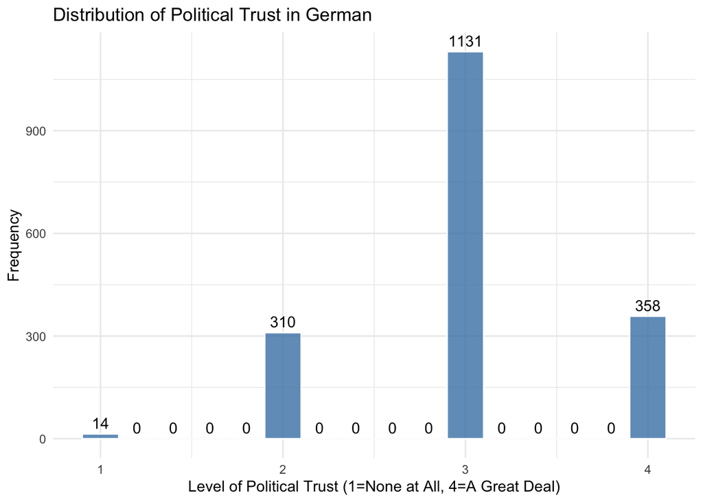

```r
# Draw the plots
# Histogram of pol trust
p1 <- ggplot(df_de, aes(x = pol_trust)) +
  geom_histogram(binwidth = 0.2, fill = "steelblue", color = "white", alpha = 0.8) +
  geom_text(stat = "bin", binwidth = 0.2,
            aes(label = ..count..), vjust = -0.5, color = "black") +
  labs(title = "Distribution of Political Trust in German",
       x = "Level of Political Trust (1=None at All, 4=A Great Deal)",
       y = "Frequency") +
  theme_minimal()

print(p1)
```

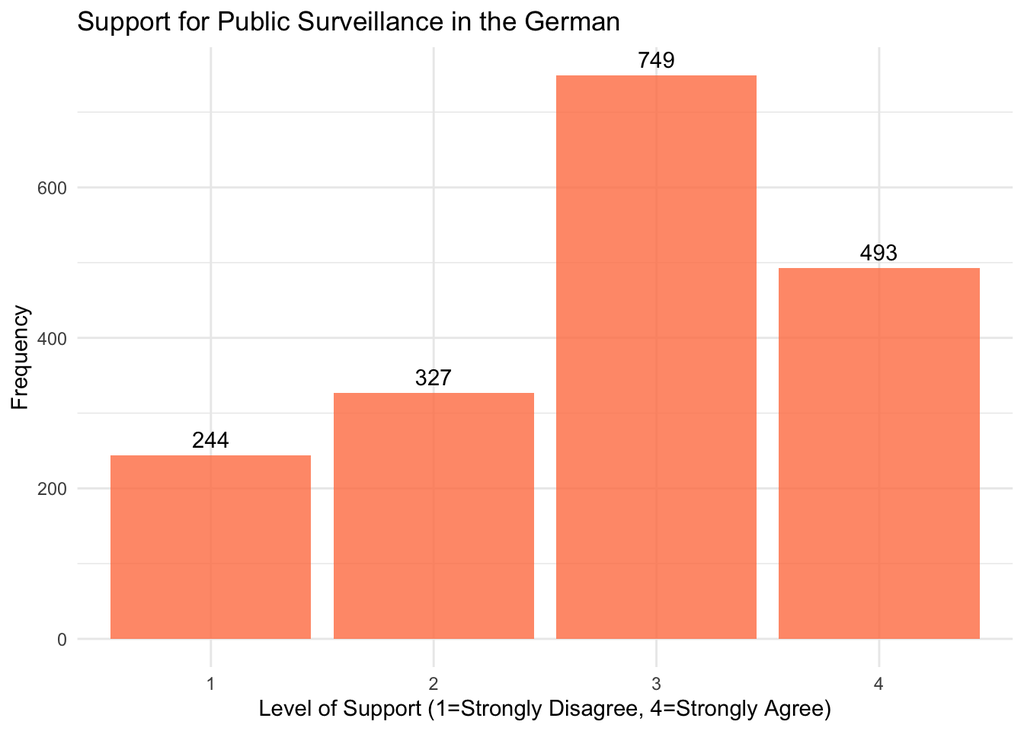

```r
ggsave(here("figures","GE_pol_trust_hist.png"), p1, width = 8, height = 6)

# Barchart of support_camera
p2 <- ggplot(df_de, aes(x = support_camera)) +
  geom_bar(fill = "coral", alpha = 0.8) +
  geom_text(stat = "count", aes(label = ..count..),
            vjust = -0.5, color = "black") +
  labs(title = "Support for Public Surveillance in the German",
       x = "Level of Support (1=Strongly Disagree, 4=Strongly Agree)",
       y = "Frequency") +
  theme_minimal()

print(p2)
```

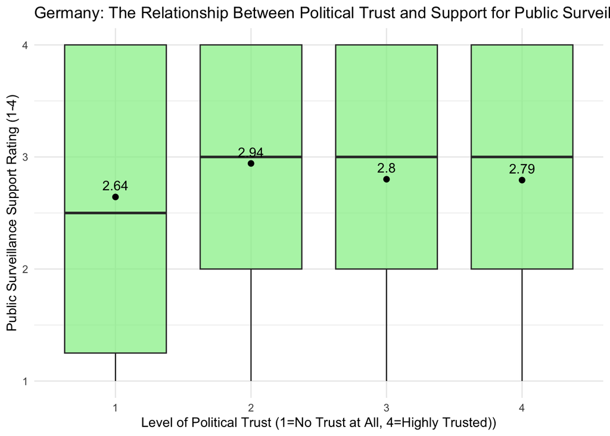

```r
ggsave(here("figures","GE_support_camera_bar.png"), p2, width = 8, height = 6)

# Relationship between political trust and support for public surveillance
# Boxplot
p3 <- ggplot(df_de, aes(x = factor(pol_trust), y = as.numeric(support_camera))) +
  geom_boxplot(fill = "lightgreen", alpha = 0.7) +
  stat_summary(fun = mean, geom = "point", shape = 20, size = 3, color = "black") +
  stat_summary(fun = mean, geom = "text", aes(label = round(..y.., 2)),
               vjust = -0.7, color = "black") +
  labs(title = "Germany: The Relationship Between Political Trust and Support for Public Surveillance",
       x = "Level of Political Trust (1=No Trust at All, 4=Highly Trusted))",
       y = "Public Surveillance Support Rating (1-4)") +
  theme_minimal()

print(p3)
```

```r
ggsave(here("figures","GE_trust_vs_support_boxplot.png"), p3, width = 8, height = 6)

# H1 Validation
# Logistic regression
model_de_v205 <- polr(support_camera ~ pol_trust + age + gender + edu_level + soc_trust,
                      data = df_de, Hess = TRUE)

# Model Summary
summary(model_de_v205)
```

```
## Call:
## polr(formula = support_camera ~ pol_trust + age + gender + edu_level +
##     soc_trust, data = df_de, Hess = TRUE)
##
## Coefficients:
##                 Value Std. Error t value
## pol_trust    -0.12201   0.071118  -1.716
## age           0.01789   0.002545   7.032
## genderFemale -0.22645   0.087138  -2.599
## edu_level.L   0.19260   0.107566   1.791
## edu_level.Q  -0.10112   0.077975  -1.297
## soc_trust     0.28297   0.091643   3.088
##
## Intercepts:
##     Value   Std. Error t value
## 1|2 -1.0015  0.2786    -3.5945
## 2|3  0.1096  0.2760     0.3972
## 3|4  1.9337  0.2812     6.8766
##
## Residual Deviance: 4632.485
## AIC: 4650.485
```

```r
# Hypothesis test for parallel lines
lipsitz_test <- lipsitz.test(model_de_v205)
print(lipsitz_test)
```

```
##
##  Lipsitz goodness of fit test for ordinal response models
##
## data:  formula:  support_camera ~ pol_trust + age + gender + edu_level + soc_trust
## LR statistic = 11.16, df = 9, p-value = 0.2649
```

```r
# Calculate results
# Coefficient Table
coef_summary <- coef(summary(model_de_v205))
coef_summary <- coef_summary[!grepl("\\|", rownames(coef_summary)), ]

# OR
odds_ratio <- exp(coef_summary[, "Value"])

# CI
ci <- exp(confint(model_de_v205))
ci <- ci[!grepl("\\|", rownames(ci)), ]

# p-value
t_value <- coef_summary[, "t value"]
p_value <- 2 * (1 - pnorm(abs(t_value)))

# table
results_table <- data.frame(
  Variable    = rownames(coef_summary),
  Coefficient = coef_summary[, "Value"],
  Odds_Ratio  = odds_ratio,
  CI_Lower    = ci[, 1],
  CI_Upper    = ci[, 2],
  p_value     = p_value
)

results_table[] <- lapply(results_table, function(x) if(is.numeric(x)) round(x, 3) else x)

print(results_table)
```

```
##                  Variable Coefficient Odds_Ratio CI_Lower CI_Upper
## pol_trust       pol_trust      -0.122      0.885    0.770    1.017
## age                   age       0.018      1.018    1.013    1.023
## genderFemale genderFemale      -0.226      0.797    0.672    0.946
## edu_level.L   edu_level.L       0.193      1.212    0.982    1.497
## edu_level.Q   edu_level.Q      -0.101      0.904    0.776    1.053
## soc_trust       soc_trust       0.283      1.327    1.109    1.588
##              p_value
## pol_trust      0.086
## age            0.000
## genderFemale   0.009
## edu_level.L    0.073
## edu_level.Q    0.195
## soc_trust      0.002
```

```r
write.csv(results_table, here("outputs","GE_model_results.csv"), row.names = FALSE)

# Overall fitting index of computational models
# Calculate the R-squared
null_model <- polr(support_camera ~ 1, data = df_de, Hess = TRUE)
loglik_ratio <- -2*(logLik(null_model) - logLik(model_de_v205))
mcfadden_r2 <- as.numeric(1 - logLik(model_de_v205)/logLik(null_model))

cat("Model Fit Metric:\n")
```

```
## Model Fit Metric:
```

```r
cat("Log-likelihood ratio:", loglik_ratio, "\n")
```

```
## Log-likelihood ratio: 74.61862
```

```r
cat("McFadden's R-squared:", mcfadden_r2, "\n")
```

```
## McFadden's R-squared: 0.01585234
```

```r
cat("AIC:", AIC(model_de_v205), "\n")
```

```
## AIC: 4650.485
```

```r
# Visualization
# Calculate the marginal effects of political trust
effect_plot <- effect("pol_trust", model_de_v205,
                      xlevels = list(pol_trust = 1:4))
effect_df <- as.data.frame(effect_plot)


colnames(effect_df)
```

```
##  [1] "pol_trust"   "prob.X1"     "prob.X2"     "prob.X3"
##  [5] "prob.X4"     "logit.X1"    "logit.X2"    "logit.X3"
##  [9] "logit.X4"    "se.prob.X1"  "se.prob.X2"  "se.prob.X3"
## [13] "se.prob.X4"  "se.logit.X1" "se.logit.X2" "se.logit.X3"
## [17] "se.logit.X4" "L.prob.X1"   "L.prob.X2"   "L.prob.X3"
## [21] "L.prob.X4"   "U.prob.X1"   "U.prob.X2"   "U.prob.X3"
## [25] "U.prob.X4"   "L.logit.X1"  "L.logit.X2"  "L.logit.X3"
## [29] "L.logit.X4"  "U.logit.X1"  "U.logit.X2"  "U.logit.X3"
## [33] "U.logit.X4"
```

```r
head(effect_df)
```

```
##   pol_trust   prob.X1   prob.X2   prob.X3   prob.X4  logit.X1
## 1         1 0.1032046 0.1558289 0.4251510 0.3158155 -2.162114
## 2         2 0.1150565 0.1680743 0.4268073 0.2900620 -2.040101
## 3         3 0.1280751 0.1804613 0.4258703 0.2655933 -1.918087
## 4         4 0.1423298 0.1928261 0.4223605 0.2424837 -1.796073
##    logit.X2   logit.X3   logit.X4 se.prob.X1  se.prob.X2 se.prob.X3
## 1 -1.689597 -0.3016629 -0.7730694 0.01480946 0.016272025 0.01240555
## 2 -1.599337 -0.2948895 -0.8950831 0.01027591 0.011191782 0.01194278
## 3 -1.513225 -0.2987203 -1.0170969 0.00780405 0.009089667 0.01191650
## 4 -1.431750 -0.3130909 -1.1391106 0.01202117 0.011982986 0.01217049
##   se.prob.X4 se.logit.X1 se.logit.X2 se.logit.X3 se.logit.X4
## 1 0.03268739  0.16000985  0.12369815  0.05075971  0.15127724
## 2 0.01821298  0.10092382  0.08004116  0.04881721  0.08844431
## 3 0.01045976  0.06988378  0.06146026  0.04873729  0.05362510
## 4 0.01647502  0.09847604  0.07698961  0.04988475  0.08969151
##    L.prob.X1 L.prob.X2 L.prob.X3 L.prob.X4 U.prob.X1 U.prob.X2
## 1 0.07757736 0.1265249 0.4010361 0.2554854 0.1360490 0.1904401
## 2 0.09639764 0.1472650 0.4035802 0.2557016 0.1367803 0.1911648
## 3 0.11354244 0.1633262 0.4026961 0.2456034 0.1441652 0.1989667
## 4 0.12035396 0.1704209 0.3987052 0.2116676 0.1675539 0.2174050
##   U.prob.X3 U.prob.X4 L.logit.X1 L.logit.X2 L.logit.X3 L.logit.X4
## 1 0.4496276 0.3830621  -2.475728  -1.932041 -0.4011501  -1.069567
## 2 0.4503617 0.3270109  -2.237908  -1.756215 -0.3905695  -1.068431
## 3 0.4493748 0.2865921  -2.055057  -1.633685 -0.3942437  -1.122200
## 4 0.4463774 0.2762143  -1.989083  -1.582647 -0.4108632  -1.314903
##   U.logit.X1 U.logit.X2 U.logit.X3 U.logit.X4
## 1  -1.848501  -1.447153 -0.2021757 -0.4765714
## 2  -1.842294  -1.442459 -0.1992095 -0.7217355
## 3  -1.781117  -1.392765 -0.2031970 -0.9119936
## 4  -1.603064  -1.280854 -0.2153186 -0.9633185
```

```r
# Identify the response category
effect_long <- effect_df %>%
  pivot_longer(cols = starts_with("prob.X"),
               names_to = "response",
               values_to = "prob")

max_prob_points <- effect_long %>%
  group_by(pol_trust) %>%
  filter(prob == max(prob)) %>%
  ungroup()

print(max_prob_points)
```

```
## # A tibble: 4 × 31
##   pol_trust logit.X1 logit.X2 logit.X3 logit.X4 se.prob.X1 se.prob.X2
##       <dbl>    <dbl>    <dbl>    <dbl>    <dbl>      <dbl>      <dbl>
## 1         1    -2.16    -1.69   -0.302   -0.773    0.0148     0.0163
## 2         2    -2.04    -1.60   -0.295   -0.895    0.0103     0.0112
## 3         3    -1.92    -1.51   -0.299   -1.02     0.00780    0.00909
## 4         4    -1.80    -1.43   -0.313   -1.14     0.0120     0.0120
## # ℹ 24 more variables: se.prob.X3 <dbl>, se.prob.X4 <dbl>,
## #   se.logit.X1 <dbl>, se.logit.X2 <dbl>, se.logit.X3 <dbl>,
## #   se.logit.X4 <dbl>, L.prob.X1 <dbl>, L.prob.X2 <dbl>,
## #   L.prob.X3 <dbl>, L.prob.X4 <dbl>, U.prob.X1 <dbl>,
## #   U.prob.X2 <dbl>, U.prob.X3 <dbl>, U.prob.X4 <dbl>,
## #   L.logit.X1 <dbl>, L.logit.X2 <dbl>, L.logit.X3 <dbl>,
## #   L.logit.X4 <dbl>, U.logit.X1 <dbl>, U.logit.X2 <dbl>, …
```

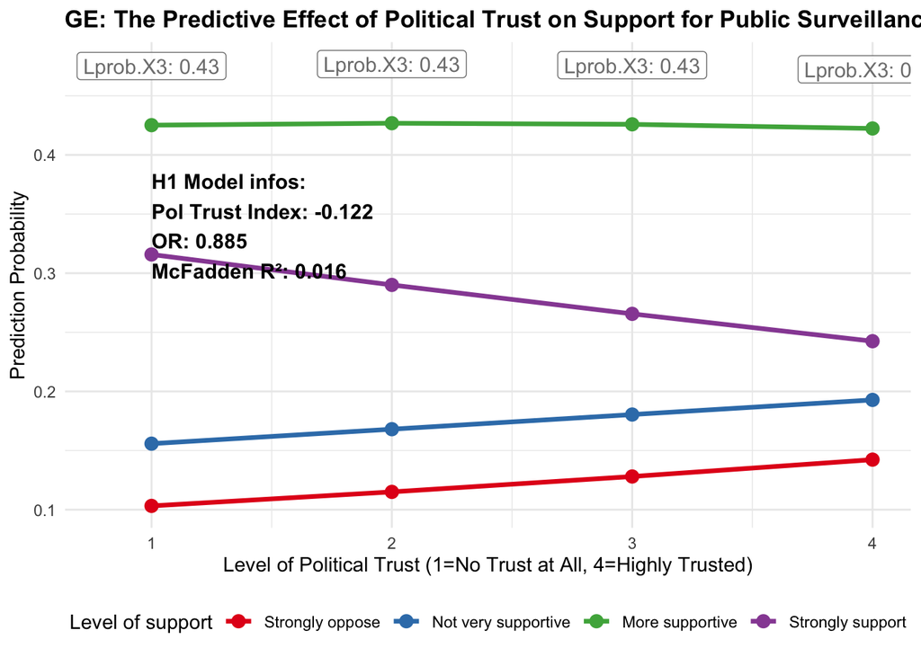

```r
effect_long <- effect_long %>%
  mutate(response = recode(response,
                           "prob.X1" = "1",
                           "prob.X2" = "2",
                           "prob.X3" = "3",
                           "prob.X4" = "4"))

# Plot the effect diagram
p4 <- ggplot(effect_long, aes(x = pol_trust, y = prob, color = response)) +
  geom_line(size = 1.2) +
  geom_point(size = 3) +
  geom_label(data = max_prob_points,
             aes(label = paste("L", response, ": ", round(prob, 2), sep = "")),
             nudge_y = 0.05,
             show.legend = FALSE,
             size = 4,
             alpha = 0.8) +
  labs(title = "GE: The Predictive Effect of Political Trust on Support for Public Surveillance",
       x = "Level of Political Trust (1=No Trust at All, 4=Highly Trusted)",
       y = "Prediction Probability",
       color = "Level of support") +
  scale_color_manual(
    values = c("1" = "#E41A1C", "2" = "#377EB8", "3" = "#4DAF4A", "4" = "#984EA3"),
    labels = c("1" = "Strongly oppose", "2" = "Not very supportive", "3" = "More supportive", "4" = "Strongly support")
  ) +
  scale_x_continuous(breaks = 1:4) +
  theme_minimal() +
  theme(
    legend.position = "bottom",
    plot.title = element_text(size = 13, face = "bold"),
    plot.subtitle = element_text(size = 12, color = "gray50")
  )
# Add statistical annotations
# Calculate the overall impact of political trust on support levels
overall_effect <- coef(model_de_v205)["pol_trust"]
odds_ratio <- exp(overall_effect)
# Create an information box
info_text <- paste(
  "H1 Model infos:\n",
  "Pol Trust Index: ", round(overall_effect, 3), "\n",
  "OR: ", round(odds_ratio, 3), "\n",
  "McFadden R²: ", round(mcfadden_r2, 3),
  sep = ""
)

# Image of the information box
p5 <- p4 +
  annotate("text",
           x = 1, y = max(effect_long$prob) * 0.9,
           label = info_text,
           hjust = 0, vjust = 1,
           size = 4,
           color = "black",
           fontface = "bold") +
  annotate("rect",
           xmin = 0.8, xmax = 2.2,
           ymin = max(effect_df$prob) * 0.7, ymax = max(effect_df$prob) * 0.95,
           alpha = 0.1, fill = "lightblue")
print(p5)
```

```r
ggsave(here("figures","GE_effect_plot_with_stats.png"), p5, width = 10, height = 7)

# Create detailed tables of probability distributions for each confidence level
prob_table <- effect_df %>%
  dplyr::select(pol_trust, prob.X1, prob.X2, prob.X3, prob.X4) %>%
  dplyr::rename(
    L1 = prob.X1,
    L2 = prob.X2,
    L3 = prob.X3,
    L4 = prob.X4
  ) %>%
  dplyr::mutate(across(where(is.numeric), ~ round(., 3)))

write.csv(prob_table, here("outputs","GE_probability_table.csv"), row.names = FALSE)
```

# Results

## Descriptive Statistics

The analysis is based on a German sample of 1813 respondents. Both key variables are measured on 1–4 scales. Political trust is concentrated at the upper-middle range; support for cameras is also high on average. This baseline pattern suggests the German sample is not distrust-heavy and is broadly favorable to public video surveillance. Variation remains sufficient for multivariate estimation.

## H1 Test in Germany

### H1: Higher levels of political trust are associated with greater public support for video surveillance in public areas.

In Germany, the ordinal logit shows a small negative link between political trust and support for cameras (β = −0.122, OR = 0.885, p = 0.086), with age increasing support (OR = 1.018, p < .001), women less supportive (OR = 0.797, p = 0.009), and social trust increasing support (OR = 1.327, p = .002); assumptions hold (Lipsitz p = .265) and overall fit is modest (McFadden R² = .016).

This pattern of probability redistribution—away from the highest support category and toward the lowest—is consistent with a negative coefficient for political trust. The shallow slopes of the lines confirm that the magnitude of the relationship is small. Therefore, H1 is not supported in the German context, the findings suggest a slight negative rather than a positive effect.

```
## Call:
## polr(formula = support_email ~ pol_trust + age + gender + edu_level +
##     soc_trust, data = df_de, Hess = TRUE)
##
## Coefficients:
##                  Value Std. Error t value
## pol_trust    -0.173193   0.070895 -2.4430
## age           0.013962   0.002568  5.4379
## genderFemale  0.009796   0.087979  0.1113
## edu_level.L   0.041624   0.109261  0.3810
## edu_level.Q  -0.190387   0.078730 -2.4182
## soc_trust     0.148367   0.092307  1.6073
##
## Intercepts:
##     Value   Std. Error t value
## 1|2  0.0561  0.2790     0.2012
## 2|3  1.5435  0.2812     5.4897
## 3|4  3.2275  0.2947    10.9520
##
## Residual Deviance: 4387.392
## AIC: 4405.392
```

```
## Call:
## polr(formula = support_phone ~ pol_trust + age + gender + edu_level +
##     soc_trust, data = df_de, Hess = TRUE)
##
## Coefficients:
##                  Value Std. Error t value
## pol_trust    -0.167103   0.075683 -2.2079
## age          -0.001815   0.002724 -0.6662
## genderFemale -0.285147   0.094982 -3.0021
## edu_level.L   0.240307   0.121478  1.9782
## edu_level.Q  -0.134421   0.086255 -1.5584
## soc_trust     0.277434   0.099659  2.7838
##
## Intercepts:
##     Value   Std. Error t value
## 1|2  0.1930  0.2980     0.6476
## 2|3  1.4513  0.3003     4.8326
## 3|4  2.9533  0.3170     9.3175
##
## Residual Deviance: 3709.314
## AIC: 3727.314
```

```
##                        Model Coefficient Odds_Ratio CI_Lower
## 1 v205 (Public Surveillance)      -0.122      0.885    0.770
## 2    v206 (Email Monitoring)      -0.173      0.841    0.732
## 3    v207 (Phone Monitoring)      -0.167      0.846    0.729
##   CI_Upper Standard_Error
## 1    1.017          0.071
## 2    0.966          0.071
## 3    0.981          0.076
```

```
## Gradient pattern partial support: Both v206 and v207 are more negative than v205, but not completely monotonic.
## Coefficient Order: -0.122 > -0.173 > -0.167
```

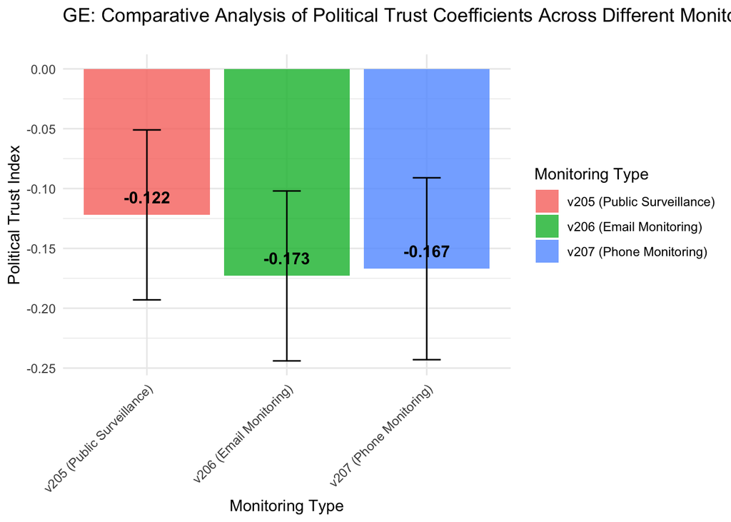

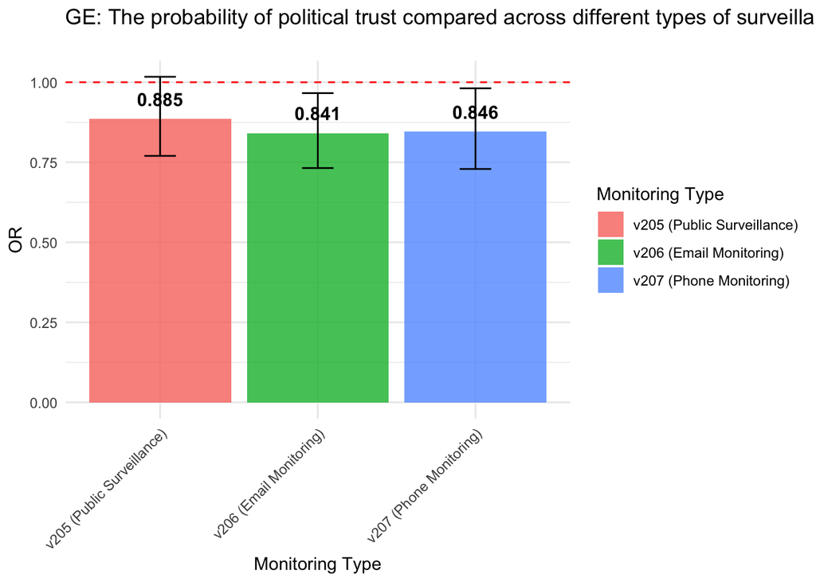

```
##                                    Model     AIC McFadden_R2
## pol_trust...1 v205 (Public Surveillance) 4650.49      0.0159
## pol_trust...2    v206 (Email Monitoring) 4405.39      0.0101
## pol_trust...3  v207 (Phone surveillance) 3727.31      0.0068
##               Coefficient    OR
## pol_trust...1      -0.122 0.885
## pol_trust...2      -0.173 0.841
## pol_trust...3      -0.167 0.846
```

```
## H2 hypothesis is partially supported: More intrusive measures are relatively more negative than cameras, but the relationship is not completely monotonic or entirely significant.
```

```
## p-value of the political trust coefficient:
```

```
## v205: 0.0862
```

```
## v206: 0.0146
```

```
## v207: 0.0272
```

## H2 Test in Germany

### H2: The positive effect of political trust on support for surveillance will weaken as the intrusiveness of the surveillance measure increases (from public area surveillance to internet monitoring to collecting information without knowledge).

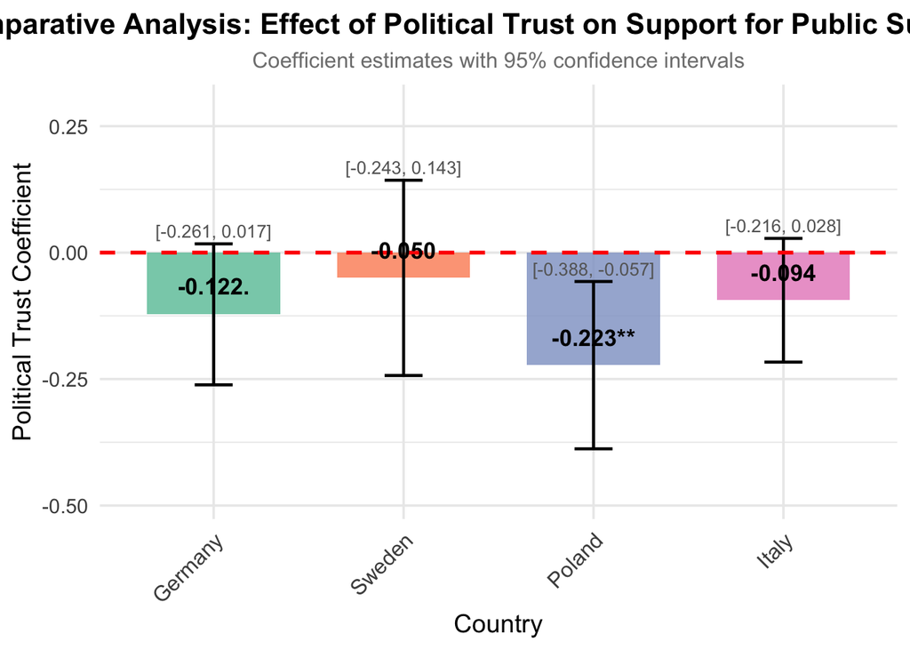

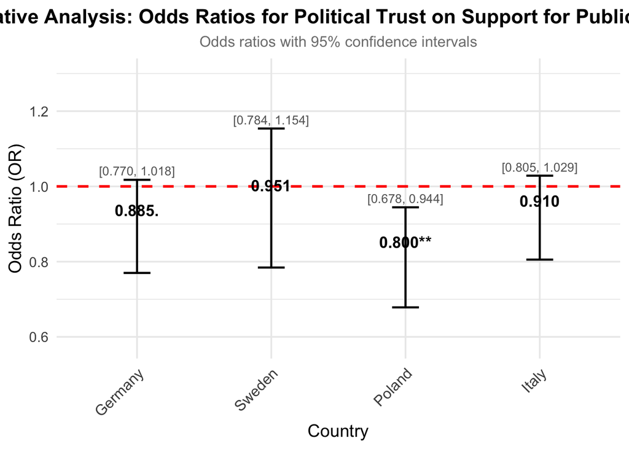

```
## Statistical Significance of Political Trust Coefficients:
```

```
## Germany: β = -0.122, p = 0.0862.
## Sweden: β = -0.050, p = 0.6124
## Poland: β = -0.223, p = 0.0084**
## Italy: β = -0.094, p = 0.1313
```

```
##
## Goodness of Fit (McFadden's R²):
```

```
## Germany: 0.0159
## Sweden: 0.0387
## Poland: 0.0144
## Italy: 0.0079
```

```
##
## KEY FINDINGS
```

```
## 1. Effect of Political Trust on Surveillance Support:
```

```
##    - Germany: marginally significant negative effect (β=-0.122, p=0.0862)
##    - Sweden: not significant negative effect (β=-0.050, p=0.6124)
##    - Poland: significant negative effect (β=-0.223, p=0.0084)
##    - Italy: not significant negative effect (β=-0.094, p=0.1313)
```

```
##
## 2. Cross-Country Differences:
```

```
##    - Poland shows the strongest and most significant negative effect
```

```
##    - Effects are consistently negative across all countries
```

```
##    - Magnitude varies substantially between countries
```

```
##
## 3. Control Variables (see detailed table):
```

```
##    - Age: Positive effect in Sweden, Italy, and Germany
```

```
##    - Gender: Women less supportive in Sweden, Poland, and Germany
```

```
##    - Social Trust: Positive effect in Sweden, Italy, and Germany
```

```
## [1] "/Users/talenthy/Desktop/MASS/finalpaper/finalpaper"
```

# Cross-country comparison

Patterns for controls are broadly similar: age is positively related to support in Sweden, Italy, and Germany; women are less supportive in Sweden, Poland, and Germany; and social trust is positive in Sweden, Italy, and Germany (not significant in Poland).

Overall, the direction of the political-trust effect is the same across cases (negative), but its magnitude and certainty differ, with Poland driving the clearest result.

# Discussion

The findings present a clear challenge to the conventional theoretical expectation that political trust facilitates public acceptance of state surveillance. In Germany, the relationship is negative, albeit modest and marginally significant. This suggests that for Germans, higher political trust does not translate into a greater willingness to authorize surveillance in public spaces. This counterintuitive result may be rooted in Germany’s historical context, where past experiences with oppressive state surveillance have engendered a deep-seated cultural value for privacy and a normative skepticism of state monitoring powers. In this environment, trust might be associated with expectations of government restraint rather than expansion of power.

The cross-country comparison further nuances this finding. The consistently negative sign of the coefficient across all four nations indicates that a positive relationship is not the default. The strong and significant effect in Poland is particularly notable and warrants further investigation into its political and social roots. The non-significant results in Sweden and Italy suggest that other factors, not captured by this model, may be the primary drivers of attitudes toward surveillance in those contexts.

# Limitations and Future Research

This study has several limitations. First, the measure of political trust relies on confidence in political parties, which is often the least trusted institution. A multi-item index measuring trust in various institutions might provide a more robust predictor. Second, the cross-sectional data prevents any causal claims. Longitudinal designs could better establish how changes in trust influence attitudes over time. Finally, the historical and cultural mechanisms proposed to explain the national differences are not directly measured. An alternative account is that fear of crime or threat perceptions (not modeled here) may drive surveillance acceptance more than trust per se. Future qualitative research could delve deeper into how citizens in these countries rationalize their attitudes based on their perceptions of the state and its history.

# Conclusion

This study set out to investigate the role of political trust in shaping public attitudes toward state surveillance. The results from Germany and the comparative analysis largely contradict the hypothesis derived from theories of political legitimacy. Rather than acting as a facilitator, higher political trust was found to be associated with lower support for surveillance, or was insignificant, across all national contexts studied. This underscores that the relationship between trust and acceptance of state power is not straightforward or universal. It is critically mediated by national political culture and historical legacy. The findings imply that governments cannot assume that a trusting public will automatically endorse the expansion of state surveillance apparatuses. Public opinion is formed at the complex intersection of trust, historical memory, and deeply held values about privacy and the proper role of the state.

# References

Easton, D. (1975). A Re-Assessment of the Concept of Political Support. British Journal of Political Science, 5(4), 435–457.

Levi, M., & Stoker, L. (2000). Political Trust and Trustworthiness. Annual Review of Political Science, 3(1), 475–507.

Tyler, T. R. (2006). Why People Obey the Law. Princeton University Press.